# Exploratory data analysis for NeuroColombia research project

Data analysis notebook

Author

Affiliation

Daniel Manrique-Castano, PhD

Digital Research Alliance of Canada

Published

Friday, April 4, 2025

Keywords

Epidemiology, Neuropsychology, Mental healh, Colombia

## 0.1 Install and load packages

We install the required packages to perform exploratory data visualization and statistical inference.

```r
if (!requireNamespace("brms", quietly = TRUE)) install.packages("brms")
if (!requireNamespace("dplyr", quietly = TRUE)) install.packages("dplyr")
if (!requireNamespace("ggplot2", quietly = TRUE)) install.packages("ggplot2")
if (!requireNamespace("ggridges", quietly = TRUE)) install.packages("ggridges")
if (!requireNamespace("ggbeeswarm", quietly = TRUE)) install.packages("ggbeeswarm")
if (!requireNamespace("gt", quietly = TRUE)) install.packages("gt")
if (!requireNamespace("here", quietly = TRUE)) install.packages("here")
if (!requireNamespace("hrbrthemes", quietly = TRUE)) install.packages("hrbrthemes")
if (!requireNamespace("tidyr", quietly = TRUE)) install.packages("tidyr")


library(brms)
library(dplyr)
library(ggplot2)
library(ggridges)
library(ggbeeswarm)
library(gt)
library(here)
library(hrbrthemes)
library(tidyr)
```

We load additional functions

```r
Plot_theme <- theme_classic() +
  theme(
      plot.title = element_text(size=18, face="bold", hjust = 0.5, vjust = 2),
      plot.subtitle = element_text(size = 10, color = "black"),
      plot.caption = element_text(size = 12, color = "black"),
      axis.line = element_line(colour = "black", linewidth = 1.5, linetype = "solid"),
      axis.ticks.length=unit(7,"pt"),

      axis.title.x = element_text(colour = "black", size = 16, vjust = -2),
      axis.text.x = element_text(colour = "black", size = 16, angle = 0, hjust = 0.5),
      axis.ticks.x = element_line(colour = "black", linewidth = 1),

      axis.title.y = element_text(colour = "black", size = 16, vjust = 3),
      axis.text.y = element_text(colour = "black", size = 16),
      axis.ticks.y = element_line(colour = "black", linewidth = 1),

      legend.position="right",
      legend.direction="vertical",
      legend.title = element_text(colour="black", face="bold", size=12),
      legend.text = element_text(colour="black", size=10),

      plot.margin = margin(t = 10,  # Top margin
                             r = 5,  # Right margin
                             b = 10,  # Bottom margin
                             l = 10) # Left margin
      )
```

# 1 Load the dataset

```r
Neuro_Data <- read.csv("Data_Processed/Ministery_DiagnosticData_Compiled.csv")
```

# 2 Temporal evolution of neuropsychological diagnostics

In the first place, we will expero the temporal evoluction of neuropsychological diagnostics in Colombia.

# 3 Total number of cases

First, we create a summary of the number of cases to show the overall trend.

```r
Summary_year<- Neuro_Data %>%
  group_by(Year) %>%
  summarise(Total_Diagnostics = sum(Cases, na.rm = TRUE)) %>%
  ungroup()

Summary_year
```

```
# A tibble: 7 × 2
   Year Total_Diagnostics
  <int>             <int>
1  2016            154453
2  2017            194102
3  2018            231242
4  2019            332318
5  2020            179859
6  2021            240548
7  2022            283661
```

We create a line visualizatyion using `ggplot`:

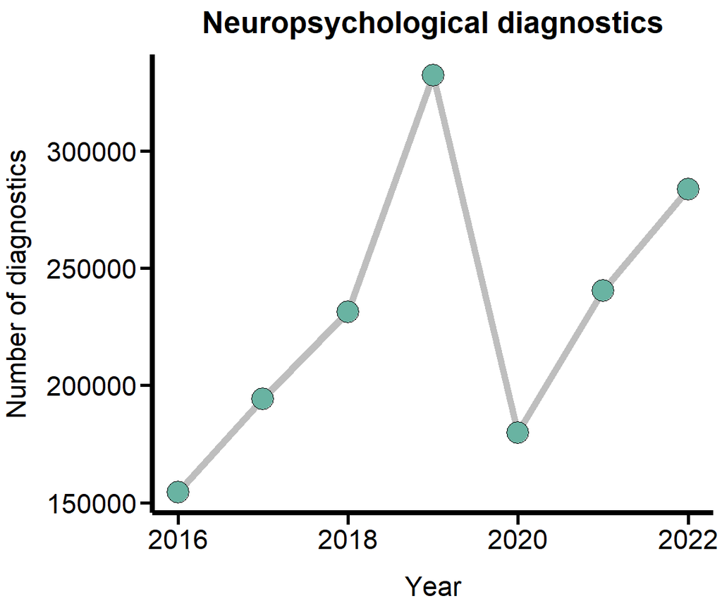

Distribution of neuropsychological diagnostics per year

```r
Diagnostic_Year_fig <- Summary_year %>%
  ggplot( aes(x= Year, y=Total_Diagnostics)) +
    geom_line( color="grey", size= 2) +
    geom_point(shape=21, color="black", fill="#69b3a2", size=6) +
    ggtitle("Neuropsychological diagnostics") +
  labs(y = "Number of diagnostics",
       x = "Year") +
    Plot_theme

ggsave(Diagnostic_Year_fig,
       filename = "Plots/Diagnostic_Year_fig.png",
       width    = 15,
       height   = 10,
       units    = "cm")

Diagnostic_Year_fig
```

Looking at the distribution in @Diagnostics_year-line, we can see that 2020 strongly disturbs the trend because of the COVID-19 pandemic, which limited the number of diagnostics in the whole country. For this reason, we consider it relevant in further analysis to make a separate analysis for the years before and after COVID. Therefore, we create the required auxiliary variables for the main `Neuro_Data` dataset:

```r
Neuro_Data <- Neuro_Data %>%
  mutate(Period = case_when(
    Year >= 2016 & Year <= 2019 ~ "Pre-Covid",
    Year >= 2020 & Year <= 2022 ~ "Post-Covid",
    TRUE ~ NA_character_
  ))
```

## 3.1 Distribution per year and capital city

```r
Summary_Year_Capital <- Neuro_Data %>%
  group_by(Year, Department, Capital) %>%
  summarise(Total_Cases = sum(Cases, na.rm = TRUE),
            Total_Population = sum(Population, na.rm = TRUE)) %>%
  ungroup()

Summary_Year_Capital$Percentage <- (Summary_Year_Capital$Total_Cases / Summary_Year_Capital$Total_Population) * 100

Summary_Year_Capital |>
  gt() |>
  opt_interactive(
    use_search = TRUE,
    use_filters = TRUE,
    use_resizers = TRUE)
```

| Year | Department | Capital | Total_Cases | Total_Population | Percentage |
| --- | --- | --- | --- | --- | --- |
| 2016 | Amazonas | No | 2 | 158 | 1.26582278481013 |
| 2016 | Amazonas | Yes | 51 | 20918 | 0.243809159575485 |
| 2016 | Antioquia | No | 6932 | 2751500 | 0.251935308013811 |
| 2016 | Antioquia | Yes | 10068 | 10228673 | 0.0984291901794104 |
| 2016 | Arauca | No | 151 | 56556 | 0.266992007921352 |
| 2016 | Arauca | Yes | 72 | 38253 | 0.188220531723002 |
| 2016 | Archipielago de San Andres, Providencia Y Santa Catalina | No | 4 | 188 | 2.12765957446809 |
| 2016 | Archipielago de San Andres, Providencia Y Santa Catalina | Yes | 22 | 8428 | 0.261034646416706 |
| 2016 | Atlantico | No | 3839 | 2579530 | 0.148825561245653 |
| 2016 | Atlantico | Yes | 5897 | 5357357 | 0.110072933351278 |

[output cut: 416 more lines]

After visualizing the data, we plot it as a scatterplot.

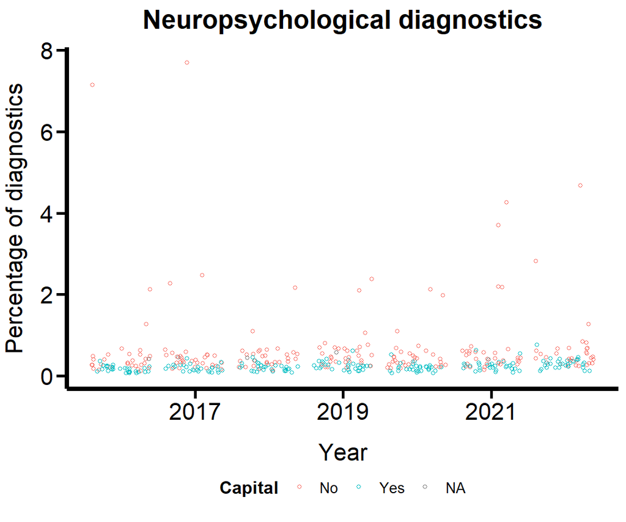

Distribution of neuropsychological diagnostics per year

```r
Year_Capital_fig <- Summary_Year_Capital %>%
  ggplot(aes(x=Year, y=Percentage, color = Capital)) +
    geom_jitter(shape=21, size=1) +
    ggtitle("Neuropsychological diagnostics") +
  labs(y = "Percentage of diagnostics",
       x = "Year") +
  Plot_theme +
  theme (legend.position = "bottom",
         legend.direction = "horizontal")

ggsave(Year_Capital_fig,
       filename = "Plots/Year_Capital_fig.png",
       width    = 15,
       height   = 15,
       units    = "cm")

Year_Capital_fig
```

Overall, @Diagnostics_year-scatter shows that the percentage of diagnoses is higher in non-capital cities. This is an aspect that we can model further.

# 4 Distribution per diagnostic

Now, we visualize the distribution of diagnostics.

```r
Summary_Diagnostic <- Neuro_Data %>%
  group_by(Diagnostic) %>%
  summarise(Total_Cases = sum(Cases, na.rm = TRUE)) %>%
  ungroup()

Summary_Year_Capital |>
  gt() |>
  opt_interactive(
    use_search = TRUE,
    use_filters = TRUE,
    use_resizers = TRUE
  )
```

| Year | Department | Capital | Total_Cases | Total_Population | Percentage |
| --- | --- | --- | --- | --- | --- |
| 2016 | Amazonas | No | 2 | 158 | 1.26582278481013 |
| 2016 | Amazonas | Yes | 51 | 20918 | 0.243809159575485 |
| 2016 | Antioquia | No | 6932 | 2751500 | 0.251935308013811 |
| 2016 | Antioquia | Yes | 10068 | 10228673 | 0.0984291901794104 |
| 2016 | Arauca | No | 151 | 56556 | 0.266992007921352 |
| 2016 | Arauca | Yes | 72 | 38253 | 0.188220531723002 |
| 2016 | Archipielago de San Andres, Providencia Y Santa Catalina | No | 4 | 188 | 2.12765957446809 |
| 2016 | Archipielago de San Andres, Providencia Y Santa Catalina | Yes | 22 | 8428 | 0.261034646416706 |
| 2016 | Atlantico | No | 3839 | 2579530 | 0.148825561245653 |
| 2016 | Atlantico | Yes | 5897 | 5357357 | 0.110072933351278 |

[output cut: 416 more lines]

We pint a bar plot using the `geom_bar` function:

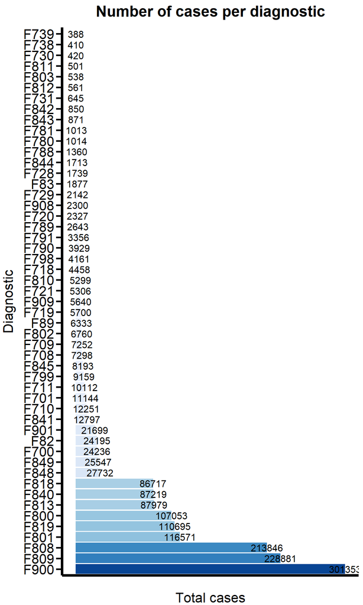

```r
# Create a bar plot with bars ordered from highest to lowest
Diagnostic_fig <- ggplot(Summary_Diagnostic,
                         aes(y = reorder(Diagnostic, -Total_Cases),
                             x = Total_Cases,
                             fill = Total_Cases)) +
  geom_bar(stat = "identity") +
  scale_fill_distiller(palette = "Blues", direction = 1) +
  geom_text(aes(label=Total_Cases), vjust=0.5, color="black", size=4)+
  labs(x = "Total cases", y = "Diagnostic", title = "Number of cases per diagnostic") +
  Plot_theme +
  theme(axis.text.x=element_blank(),
        axis.ticks.x=element_blank(),
        legend.position = "none")


ggsave(Diagnostic_fig,
       filename = "Plots/Diagnostic_fig.png",
       width    = 16,
       height   = 30,
       units    = "cm")

Diagnostic_fig
```

Based on @Diagnostics_Diagnostic, we subset and write a table keeping the main diagnostics for further analysis.

```r
Neuro_Data_MainDiag <- Neuro_Data  %>%
  filter(Diagnostic %in% c("F900", "F809", "F808", "F801", "F819", "F800", "F818", "F813", "F840"))

write.csv(Neuro_Data_MainDiag, "Data_Processed/Neuro_Data_MainDiag.csv", row.names = FALSE)
```

## 4.1 Distribution per diagnostic and sex

Now, we are interestied in exploring the distribution of diagnostics by sex

```r
Summary_Diagnostic_Sex <- Neuro_Data_MainDiag %>%
  group_by(Department, Diagnostic, Sex) %>%
  summarise(Total_Cases = sum(Cases, na.rm = TRUE),
            Total_Population = sum(Population, na.rm = TRUE)) %>%
  ungroup()

Summary_Diagnostic_Sex$Percentage <- (Summary_Diagnostic_Sex$Total_Cases / Summary_Diagnostic_Sex$Total_Population) * 100

Summary_Diagnostic_Sex |>
  gt() |>
  opt_interactive(
    use_search = TRUE,
    use_filters = TRUE,
    use_resizers = TRUE
  )
```

| Department | Diagnostic | Sex | Total_Cases | Total_Population | Percentage |
| --- | --- | --- | --- | --- | --- |
| Amazonas | F800 | Women | 2 | 1115 | 0.179372197309417 |
| Amazonas | F801 | Men | 25 | 10328 | 0.242060418280403 |
| Amazonas | F801 | Women | 16 | 7350 | 0.217687074829932 |
| Amazonas | F808 | Men | 165 | 33115 | 0.498263626755247 |
| Amazonas | F808 | Women | 91 | 26885 | 0.338478705597917 |
| Amazonas | F809 | Men | 159 | 35787 | 0.444295414536005 |
| Amazonas | F809 | Women | 63 | 20988 | 0.300171526586621 |
| Amazonas | F813 | Men | 12 | 4136 | 0.290135396518375 |
| Amazonas | F813 | Women | 5 | 2733 | 0.182949140139041 |
| Amazonas | F818 | Men | 19 | 7617 | 0.249442037547591 |

[output cut: 579 more lines]

We visualize the data for the main diagnostics as density plots using `ridges`

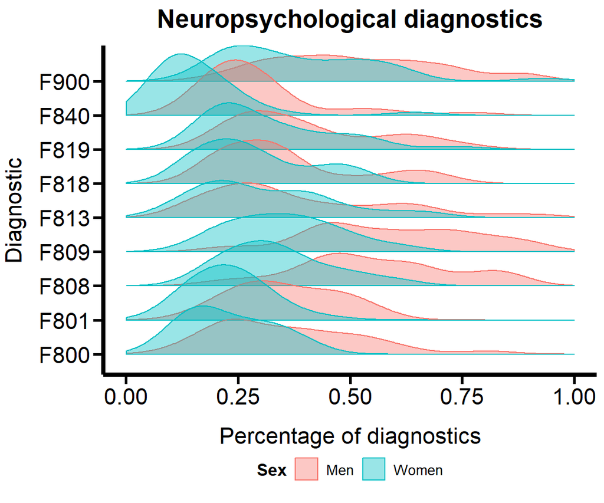

Distribution of neuropsychological diagnostics per biological sex

```r
Diagnostic_Sex_fig <- Summary_Diagnostic_Sex %>%
  ggplot(aes(x=Percentage, y=Diagnostic, color = Sex, fill = Sex)) +
    geom_density_ridges2(alpha = 0.4) +
    ggtitle("Neuropsychological diagnostics") +
    xlim(0, 1) +
  labs(y = "Diagnostic",
       x = "Percentage of diagnostics") +
  Plot_theme +
  theme (legend.position = "bottom",
         legend.direction = "horizontal")

ggsave(Diagnostic_Sex_fig,
       filename = "Plots/Diagnostic_Sex_fig.png",
       width    = 15,
       height   = 15,
       units    = "cm")

Diagnostic_Sex_fig
```

@Diagostics_sex shows that men are more likely to recieve some diagnostics.

## 4.2 Cases by sex and age

Now, we include age as a variable in the distribution by sex.

```r
Summary_Age_Sex <- Neuro_Data_MainDiag %>%
  group_by(Age, Sex) %>%
  summarise(Total_Cases = sum(Cases, na.rm = TRUE),
            Total_Population = sum(Population, na.rm = TRUE)) %>%
  ungroup()

Summary_Age_Sex$Percentage <- (Summary_Age_Sex$Total_Cases / Summary_Age_Sex$Total_Population) * 100

Summary_Age_Sex |>
  gt() |>
  opt_interactive(
    use_search = TRUE,
    use_filters = TRUE,
    use_resizers = TRUE
  )
```

| Age | Sex | Total_Cases | Total_Population | Percentage |
| --- | --- | --- | --- | --- |
| 0 | Men | 4727 | 6376029 | 0.0741370530152859 |
| 0 | Women | 3089 | 5212521 | 0.0592611521373247 |
| 1 | Men | 19728 | 8916325 | 0.221257076205724 |
| 1 | Women | 9782 | 7336143 | 0.133339821756473 |
| 2 | Men | 62522 | 11150266 | 0.560722049142146 |
| 2 | Women | 24896 | 9055769 | 0.274918673389306 |
| 3 | Men | 87159 | 12767532 | 0.68266130055519 |
| 3 | Women | 33643 | 10345685 | 0.325188713942093 |
| 4 | Men | 99897 | 14160657 | 0.705454556239869 |
| 4 | Women | 40890 | 11670956 | 0.350356903067752 |

[output cut: 14 more lines]

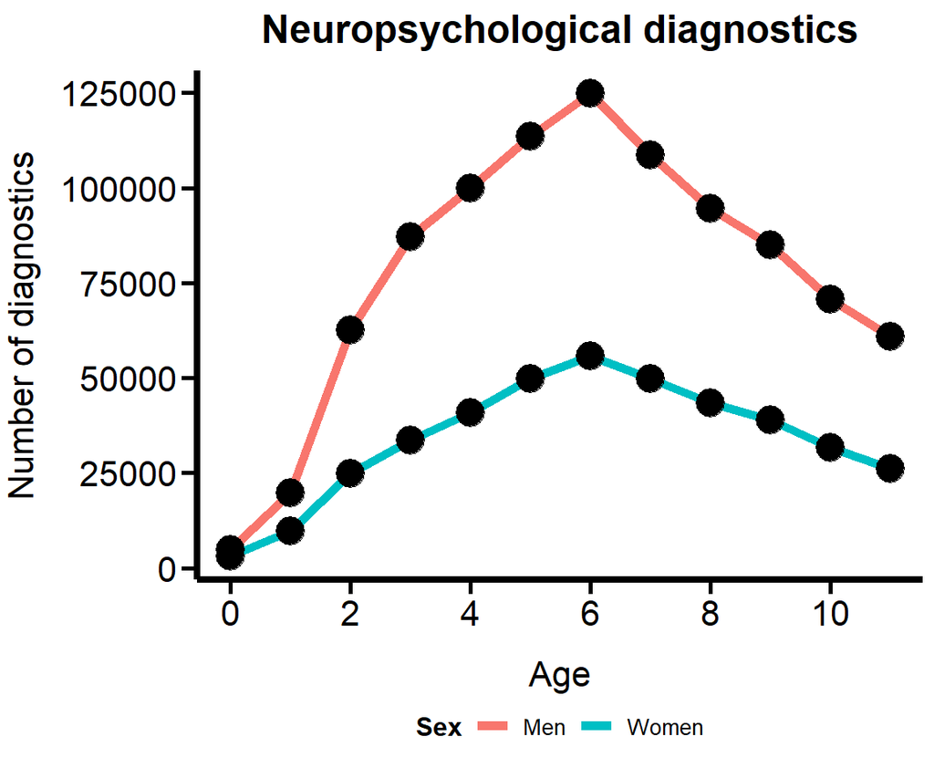

Distribution of neuropsychological diagnostics per biological sex and age

```r
Age_Sex_fig <- Summary_Age_Sex %>%
  ggplot(aes(x= Age, y= Total_Cases, color = Sex)) +
    geom_line(size= 2) +
    geom_point(shape=21, color = "black", fill = "black", size=6) +
    ggtitle("Neuropsychological diagnostics") +
  scale_x_continuous(breaks = seq(0, 11, by = 2)) +
  labs(y = "Number of diagnostics",
       x = "Age") +
  Plot_theme +
  theme (legend.position = "bottom",
         legend.direction = "horizontal")

ggsave(Age_Sex_fig ,
       filename = "Plots/Age_Sex_fig .png",
       width    = 15,
       height   = 15,
       units    = "cm")

Age_Sex_fig
```

@Diagostics_sex-age shows that males are more likely to be diagnosed, although both sexes peak at 6 years.Given the change in the trend, we find suitable to model this behaviours using splines.